# Predicting Housing Prices

# Introduction

The objective of this analysis is to build regression models and compare the results against that achievable through machine learning algorithms such as decision trees and random forests. Bagging and gradient boosting techniques are also employed later to examine how well the model performance improves. The Boston Housing dataset is used in this analysis to predict the median value of the houses. More information on the dataset can be found [here](https://www.cs.toronto.edu/~delve/data/boston/bostonDetail.html).

The packages required to run this report are available in the codeblock below.

```r
library(dplyr) #The gasoline to the caR
library(MASS) #Boston dataset
library(rsample) #Sampling data into train and test
library(boot) #Cross validate the model
library(ggplot2) #Visualization
library(tibble) #Data manipulation
library(gridExtra) #Print ggplots together
library(Hmisc) #Correlation
library(corrplot) #Correlation plot
library(knitr) #Generate HTML doc
library(car) #VIF check
library(leaps) #Best subset regression
library(ggfortify) #Residual analysis plots
library(glmnet) #Regularized regressions
library(rpart) #Decision trees
library(rpart.plot) #Plot them
library(ipred) #Decision tree Bagging
library(ranger) #Random Forest
library(gbm) #Gradient Boosting
```

Each model is constructed on a 75% training dataset and then tested against the out of sample 25% observations.

```r
opts_chunk$set(message = FALSE, warning = FALSE)

data <- Boston
set.seed(1804)
data_split <- initial_split(data, prop = .75, strata = "medv")
data_train <- training(data_split)
data_test  <- testing(data_split)
```

# Exploratory Analysis

The dataset contains 506 rows and 14 columns. The variable of interest to us is `medv` which is the median value of homes in the 1970’s. The remaining 13 columns act as predictor variables. The list of variables, along with a description and summary statistics are presented below.

```r
var_desc <- c("Crime rate",
              "Prop of zoned lots over 25k sqft",
              "Prop of non-retail business acres",
              "Close to Charles river",
              "N2O concentration",
              "Rooms",
              "Prop of owner-occupied units",
              "Distance to employment centres",
              "Access to radial highways",
              "Tax rate",
              "Pupil-Teacher ratio",
              "Black population",
              "Lower status of the population",
              "Median value of home in $1000")

summary_stats <- summary(data) %>% as.data.frame() %>%
  separate(Freq, into = c("stat", "value"), sep = ":" )
summary_stats$value <- summary_stats$value %>% as.numeric() %>%  round(2)

summary_stats <- summary_stats %>% spread(key = stat, value = value) %>%
  mutate(Description = var_desc) %>%
  dplyr::select(c(2, 9, 8, 5, 6, 7)) %>% rename("Variable" = "Var2")
summary_stats[4,5] <- summary_stats[4,6] <- NA
summary_stats %>% kable(caption = "Variabel summary statistics")
```

Variabel summary statistics

| Variable | Description | Min. | Max. | Mean | Median |
| --- | --- | --- | --- | --- | --- |
| crim | Crime rate | 0.01 | 88.98 | 3.61 | 0.26 |
| zn | Prop of zoned lots over 25k sqft | 0.00 | 100.00 | 11.36 | 0.00 |
| indus | Prop of non-retail business acres | 0.46 | 27.74 | 11.14 | 9.69 |
| chas | Close to Charles river | 0.00 | 1.00 | NA | NA |
| nox | N2O concentration | 0.38 | 0.87 | 0.55 | 0.54 |
| rm | Rooms | 3.56 | 8.78 | 6.29 | 6.21 |
| age | Prop of owner-occupied units | 2.90 | 100.00 | 68.57 | 77.50 |
| dis | Distance to employment centres | 1.13 | 12.13 | 3.80 | 3.21 |
| rad | Access to radial highways | 1.00 | 24.00 | 9.55 | 5.00 |
| tax | Tax rate | 187.00 | 711.00 | 408.20 | 330.00 |
| ptratio | Pupil-Teacher ratio | 12.60 | 22.00 | 18.46 | 19.05 |
| black | Black population | 0.32 | 396.90 | 356.67 | 391.44 |
| lstat | Lower status of the population | 1.73 | 37.97 | 12.65 | 11.36 |
| medv | Median value of home in $1000 | 5.00 | 50.00 | 22.53 | 21.20 |

The histograms show the distribution of each variable. The data appears to be exponentially distributed in some cases, skewed-normal in others. There doesn’t seem to be any glaring outliers.

The right skewed distribution of the response `medv` suggests that a log transformation on the variable could improve performance.

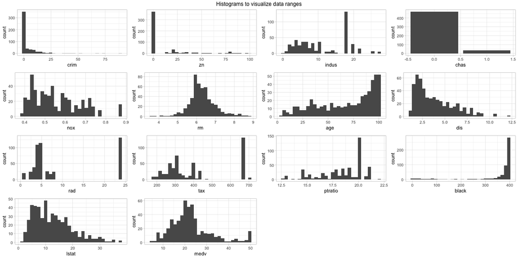

```r
histo_viz <- list()
for (i in colnames(data)) {
  if (i == "chas") {
    histo_viz[[i]] <- data %>% ggplot(aes_string(i)) + geom_bar() + theme_light()
  } else {
    histo_viz[[i]] <- data %>% ggplot(aes_string(i)) + geom_histogram() + theme_light()
  }
}
grid.arrange(grobs = histo_viz, nrow = 4, ncol = 4,
             top = "Histograms to visualize data ranges" )
```

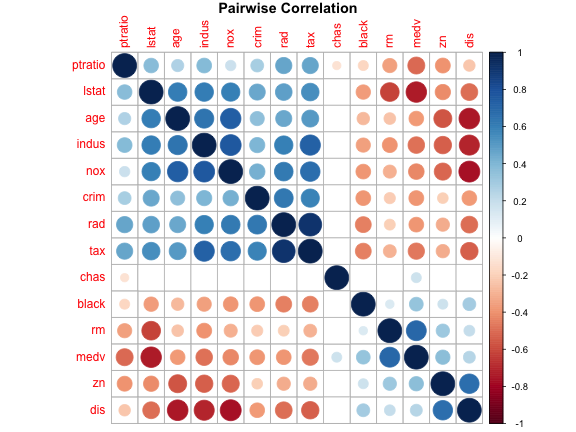

```r
cor_data <- rcorr(as.matrix(data))
corrplot(cor_data$r, type = "full", order = "hclust", title = "Pairwise Correlation",
         p.mat = cor_data$P, sig.level = 0.01, insig = "blank", mar = c(0,0,1,0))
```

# Ordinary Least Squares

The general idea behind OLS modelling is to come up with a straight line that connects as many observations as possible in n-dimensions. The mathematics is that the squares of distance between the line and the observation point must be minimal.

The function `regression` defined below accepts the formula for the `lm` and returns model evaluation parameters. It’s reused throughout this report for all OLS models.

```r
regression <- function(regression_formula) {

  set.seed(1804)
  model <- lm(as.formula(regression_formula), data_train)

  model_summary <- summary(model)
  model_predict <- predict(model, data_test)

  vif_vars <- vif(model) %>% as.data.frame() %>%
    rownames_to_column("Variable") %>% filter( . > 5)

  insig_coeff <- summary(model)$coefficients %>% as.data.frame() %>%
    rownames_to_column("Variable") %>% rename("p_value" = `Pr(>|t|)` ) %>%
    filter( p_value > 0.01) %>% dplyr::select(c(1, 2, 5))

  coef_count <- length(model$coefficients) - 1
  mse_log = (sum((exp(model$fitted.values) - data_train$medv)^2)) / (nrow(data_train) - 14)
  mspe_log = (sum((exp(model_predict) - data_test$medv)^2)/(nrow(data_test) - 14))

  export_params <- list(mse = round((model_summary$sigma)^2, 3),
                        mspe = round(mean((model_predict - data_test$medv)^2), 3),
                        rsq = round(model_summary$r.squared, 3),
                        adj_r = round(model_summary$adj.r.squared, 3),
                        aic = round(AIC(model), 0),
                        bic = round(BIC(model), 0),
                        coef_count = coef_count,
                        mse_log = round(mse_log, 3),
                        mspe_log = round(mspe_log, 3),
                        insig_coeff = insig_coeff,
                        vif_vars = vif_vars,
                        residuals = autoplot(model, which = 1:3,
                                             ncol = 3, label.n = 0) + theme_light())
  return(export_params) }
```

The table below shows what each output parameter is.

```r
data.frame(parameter = param_out, description = param_desc) %>% kable()
```

| parameter | description |
| --- | --- |
| mse | Mean Square Error |
| mspe | Out of Sample Error |
| rsq | R-Squared |
| adj_r | Adjusted R-Squared |
| aic | Akaike information criterion |
| bic | Bayesian information criterion |
| coef_count | Number of coefficients used in the model |
| mse_log | MSE, when log transform is applied on the target variable |
| mspe_log | MSPE when log transformed |
| insig_coeff | Dataframe containing insignificant coefficients. p-value threshold is 0.01 |
| vif_vars | Dataframe containing coefficients with VIF > 5 |
| residuals | Residual plots for the model |

## General Model

The first model assumes that the `medv` has a liner relationship with all the 13 variables. The formula

medv ~ .

is applied to get the following results.

```r
gen_formula <- "medv ~ ."
gen_params <- regression(regression_formula = gen_formula)
gen_out <- gen_params[1:7] %>% as.data.frame()
gen_caption <- "Basic GLM - All Variables"
gen_out %>% kable(caption = gen_caption)
```

Basic GLM - All Variables

| mse | mspe | rsq | adj_r | aic | bic | coef_count |
| --- | --- | --- | --- | --- | --- | --- |
| 19.68 | 32.594 | 0.773 | 0.765 | 2232 | 2291 | 13 |

The *R*<sup>2</sup> value of 0.773 is pretty good for a simple model. However the parameters indus, chas, age are not significant. Multicollinearity exists between these variables - rad, tax.

The plots below show the residual analyses for the model. It’s observed that `medv` with extreme values are not being captured by the regression line.

```r
gen_params$residuals
```

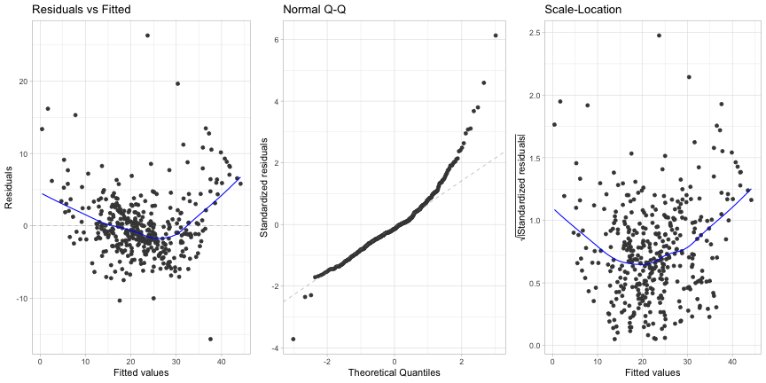

Removing the insignificant and collinear variables gives us these results.

```r
gen_insig_vif_formula <- paste0("medv ~ . -",
                                bind_rows(gen_params$insig_coeff %>% dplyr::select(1),
                                          gen_params$vif_vars %>% dplyr::select(1)) %>%
                                  pull("Variable") %>%
                                  paste(collapse = " -"))

gen_insig_vif_params <- regression(regression_formula = gen_insig_vif_formula)
gen_insig_vif_out <- gen_insig_vif_params[1:7] %>% as.data.frame()
gen_insig_vif_caption <- "GLM - Invalid parameters removed"
gen_insig_vif_out %>% kable(caption = gen_insig_vif_caption)
```

GLM - Invalid parameters removed

| mse | mspe | rsq | adj_r | aic | bic | coef_count |
| --- | --- | --- | --- | --- | --- | --- |
| 20.561 | 34.986 | 0.759 | 0.754 | 2244 | 2283 | 8 |

## Model Interpretation

The coefficients of the model above are printed below.

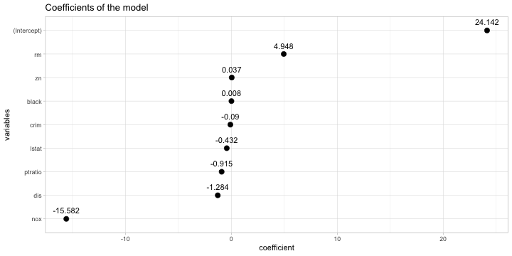

```r
coef(lm(as.formula(gen_insig_vif_formula), data = data_train)) %>% as.array() %>% as.data.frame() %>%
  rownames_to_column("variable") %>%
  rename("coefficient" = ".") %>% filter(coefficient != 0) %>%
  ggplot(aes(coefficient, reorder(variable, coefficient))) +
  geom_point(show.legend = FALSE, size = 3) +
  geom_text(aes(label = round(coefficient,3)), hjust = 0.5, vjust = -1) +
  theme(text = element_text(size = 7)) + ylab("variables") + theme_light() +
  ggtitle("Coefficients of the model")
```

This can be interpreted such that, a unit increase in `rm`, for example, would increase the housing prices by 4.948(in $1000). A unit increse in `nox` however will decrease `medv` by -15,582.

## Log Transformation

Applying log-transformation to the response variable significantly improves the MSE and *R*<sup>2</sup>. The formula

log(medv) ~ .

produces the following results. AIC and BIC do not apply to transformed regressions.

```r
log_formula <- "log(medv) ~ . "
log_params <- regression(regression_formula = log_formula)

log_params$mse <- log_params$mse_log
log_params$mspe <- log_params$mspe_log
log_params$aic <- log_params$bic <- NA

log_out <- log_params[1:7] %>% as.data.frame()
log_caption <- "medv is log-transformed"
log_out %>% kable(caption = log_caption)
```

medv is log-transformed

| mse | mspe | rsq | adj_r | aic | bic | coef_count |
| --- | --- | --- | --- | --- | --- | --- |
| 16.101 | 31.97 | 0.809 | 0.802 | NA | NA | 13 |

The insignificant parameters zn, indus, chas, age and the multicollinear parameters rad, tax are removed from the equation to get the following results.

```r
log_insig_vif_formula <- paste0("log(medv) ~ . -",
                                bind_rows(log_params$insig_coeff %>% dplyr::select(1),
                                          log_params$vif_vars %>% dplyr::select(1)) %>%
                                  pull("Variable") %>%
                                  paste(collapse = " -"))
log_insig_vif_params <- regression(regression_formula = log_insig_vif_formula)

log_insig_vif_params$aic <- log_insig_vif_params$bic <- NA
log_insig_vif_params$mse <- log_insig_vif_params$mse_log
log_insig_vif_params$mspe <- log_insig_vif_params$mspe_log

log_insig_vif_out <- log_insig_vif_params[1:7] %>% as.data.frame()
log_insig_vif_caption <- "Log - Invalid parameters removed"
log_insig_vif_out %>% kable(caption = log_insig_vif_caption)
```

Log - Invalid parameters removed

| mse | mspe | rsq | adj_r | aic | bic | coef_count |
| --- | --- | --- | --- | --- | --- | --- |
| 17.11 | 35.505 | 0.792 | 0.788 | NA | NA | 7 |

```r
log_insig_vif_params$residuals
```

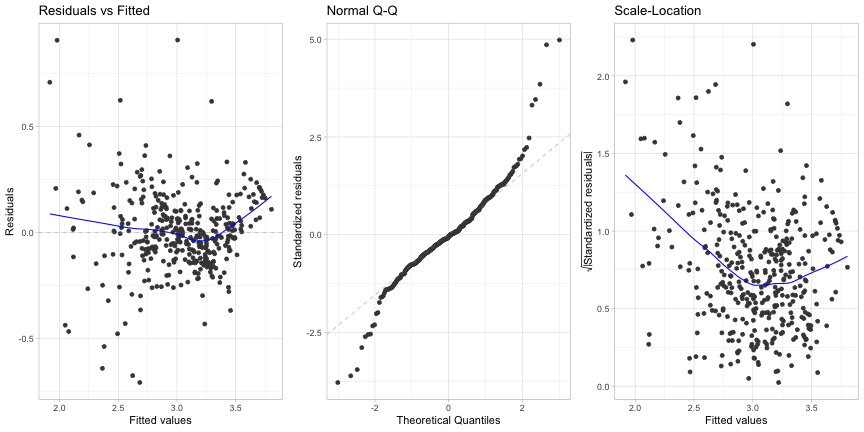

A summary of all four models so far.

```r
bind_rows(gen_out, gen_insig_vif_out, log_out ,log_insig_vif_out) %>%
  mutate(model = c(gen_caption, gen_insig_vif_caption, log_caption, log_insig_vif_caption)) %>%
  kable(caption = "GLM Summary")
```

GLM Summary

| mse | mspe | rsq | adj_r | aic | bic | coef_count | model |
| --- | --- | --- | --- | --- | --- | --- | --- |
| 19.680 | 32.594 | 0.773 | 0.765 | 2232 | 2291 | 13 | Basic GLM - All Variables |
| 20.561 | 34.986 | 0.759 | 0.754 | 2244 | 2283 | 8 | GLM - Invalid parameters removed |
| 16.101 | 31.970 | 0.809 | 0.802 | NA | NA | 13 | medv is log-transformed |
| 17.110 | 35.505 | 0.792 | 0.788 | NA | NA | 7 | Log - Invalid parameters removed |

# Variable Subsetting

## Best Subset Regression

This method of variable selection acts like a carpet bomb, evaluating models for every permutation of the variable subsets. Obviously, this does not work well when the number of features is high. It is also unlikely that any significant increase in performance would be observed for our dataset.  
The maximum size of the model is set to 13 and 10 subsets of each size are evaluated for a total of 130 models.

```r
set.seed(1804)
subset <- regsubsets(medv~., data_train, nbest = 10, nvmax = 13) %>% summary()

subset_vars <- subset$which[which.max(subset$adjr2),] %>% as.data.frame() %>%
  rownames_to_column("Variable") %>% filter(. == TRUE) %>%
  filter(Variable != "(Intercept)") %>% pull("Variable")

subset_formula = paste("medv ~", paste(subset_vars, collapse = " + "))
```

The model with the highest *a**d**j* *R*<sup>2</sup> is

medv ~ crim + zn + chas + nox + rm + dis + rad + tax + ptratio + black + lstat

It appears that the model takes only 11 out of 13 features for max performance. The variables indus, age are not included.

The measures are printed below. As expected, the model performs similarly to our original model.

```r
subset_params <- regression(regression_formula = subset_formula)
subset_params[1:7] %>% as.data.frame() %>% kable(caption = "Best subset for max adj. R2")
```

Best subset for max adj. R2

| mse | mspe | rsq | adj_r | aic | bic | coef_count |
| --- | --- | --- | --- | --- | --- | --- |
| 19.582 | 32.487 | 0.772 | 0.766 | 2228 | 2280 | 11 |

## Forward and Backward Selection

The idea behind forward selecting variables is that the model starts from no dependancy and adds one variable at a time to improve performance. It stops after it reaches a point where adding any more variables degrades the measures. Backward elimination works the oppposite, starting from all models to null. AIC is used to compare performance.

```r
set.seed(1804)

full_model <- lm(medv ~ . , data_train)
null_model <- lm(medv ~ 1 , data_train)

step_aic_forward <- stepAIC(null_model, scope = list(lower = null_model,
                                                     upper = full_model),
                            direction = "forward", trace = 0)

step_aic_backward <- stepAIC(full_model, scope = list(lower = null_model,
                                                      upper = full_model),
                             direction = "backward", trace = 0)

forward_formula <- as.character(step_aic_forward$call)[2]
backward_formula <- as.character(step_aic_backward$call)[2]
```

For our dataset, both the methods reach the same formula.

medv ~ lstat + rm + ptratio + black + dis + nox + chas + crim + zn + rad + tax

It is also noted that this formula is same as the best subset model. The measures are printed below.

```r
forward_params <- regression(regression_formula = forward_formula)
forward_params[1:7] %>% as.data.frame() %>% kable(caption = "Forward and Backward selection")
```

Forward and Backward selection

| mse | mspe | rsq | adj_r | aic | bic | coef_count |
| --- | --- | --- | --- | --- | --- | --- |
| 19.582 | 32.487 | 0.772 | 0.766 | 2228 | 2280 | 11 |

# Regularized Regression

Regularization in regression is used when the number of features is high or there exist multicollinearity between the variables. By bringing down the coefficient values, one can also improve the interpretability of the model.

Building on the Ordinary Least Square regression, a penalty parameter *P* is added to the minimizing equation that works to reduce the *β*.

*m**i**n**i**m**i**z**e* {*S**S**E* + *λ**P*}

The penalty parameter can take a wide range of values, controlled by the *λ*. The implementation also requires an *α* parameter. Setting *α* to 0 makes it a ridge regression, while lasso takes 1. Any value inbetween would be an elasticnet. Lasso and ridge differ by the definition of *P* in the formula above. Elasticnet is a combination of both lasso and ridge, incorporating *λ**P*<sub>*r**i**d**g**e*</sub> + *λ**P*<sub>*l**a**s**s**o*</sub> to the equation.

My implementation applies an elastic net regression with *α* ranging between 0 to 1, at increments of 0.01. The model with the least out-of-sample prediction error is selected. When applying the model to the test data, the minimum estimated *λ* value and the *λ* that is 1 se away from the minimum are applied. This gives us a grid of 101 *α* values against 2 *λ* for a total of 202 models.

```r
data_train_x <- model.matrix(medv ~ ., data_train)[, -14]
data_test_x <- model.matrix(medv ~ ., data_test)[, -14]

regularize_tuning <- expand.grid(alpha = seq(0, 1, by = 0.01),
                                 mse_min = 0,
                                 mspe_min = 0,
                                 coef_count_min = 0,
                                 mse_1se = 0,
                                 mspe_1se = 0,
                                 coef_count_1se = 0)

for (i in 1:nrow(regularize_tuning)) {
  set.seed(1804)

  model <- cv.glmnet(x = data_train_x, y = data_train$medv, nfolds = 5,
                     alpha = regularize_tuning$alpha[i])

  regularize_tuning$mse_min[i] <- round(model$cvm[model$lambda == model$lambda.min], 3)
  regularize_tuning$mse_1se[i] <- round(model$cvm[model$lambda == model$lambda.1se], 3)
  regularize_tuning$coef_count_min[i] <- coef(model, s = "lambda.min") %>%
    as.array() %>% as.data.frame() %>% rename(coef = "1") %>% filter(coef != 0) %>% nrow() - 1
  regularize_tuning$coef_count_1se[i] <- coef(model, s = "lambda.1se") %>%
    as.array() %>% as.data.frame() %>% rename(coef = "1") %>% filter(coef != 0) %>% nrow() - 1

  predict_min <- predict(model, s = model$lambda.min, data_test_x)
  predict_1se <- predict(model, s = model$lambda.1se, data_test_x)

  regularize_tuning$mspe_min[i] <- round(mean((predict_min - data_test$medv)^2), 3)
  regularize_tuning$mspe_1se[i] <- round(mean((predict_1se - data_test$medv)^2), 3)
}
```

The table below shows the training and testing mean error at both *λ*.*m**i**n* and *λ*.1*s**e* for *α* values with best performance. The reason why these 6 rows are selected out of 202 is explained in the last column.

```r
best_performers <- bind_rows(
  regularize_tuning %>% filter(alpha == 1) %>% mutate(condition = "alpha = 1"),
  regularize_tuning %>% filter(alpha == 0) %>% mutate(condition = "alpha = 0"),
  regularize_tuning %>% arrange(mspe_1se) %>% head(1) %>% mutate(condition = "least mspe.1se"),
  regularize_tuning %>% arrange(mse_1se) %>% head(1) %>% mutate(condition = "least mse.1se"),
  regularize_tuning %>% arrange(mspe_min) %>% head(1) %>% mutate(condition = "least mspe.min"),
  regularize_tuning %>% arrange(mse_min) %>% head(1) %>% mutate(condition = "least mse.min"))

best_performers %>% kable(caption = "Elastic Tune results")
```

Elastic Tune results

| alpha | mse_min | mspe_min | coef_count_min | mse_1se | mspe_1se | coef_count_1se | condition |
| --- | --- | --- | --- | --- | --- | --- | --- |
| 1.00 | 24.779 | 44.371 | 12 | 30.412 | 52.618 | 7 | alpha = 1 |
| 0.00 | 24.827 | 44.985 | 12 | 30.053 | 49.085 | 12 | alpha = 0 |
| 0.01 | 24.713 | 44.410 | 12 | 29.943 | 49.069 | 12 | least mspe.1se |
| 0.05 | 24.719 | 44.437 | 12 | 29.849 | 49.305 | 11 | least mse.1se |
| 1.00 | 24.779 | 44.371 | 12 | 30.412 | 52.618 | 7 | least mspe.min |
| 0.01 | 24.713 | 44.410 | 12 | 29.943 | 49.069 | 12 | least mse.min |

For the sake of model simplicity, *α* = 1 is chosen to be the best. Choosing the 1se lambda will help avoid overfitting. This essentially makes it a lasso regression with the model predicted at 1se lambda.

The coefficients of the model are printed below.

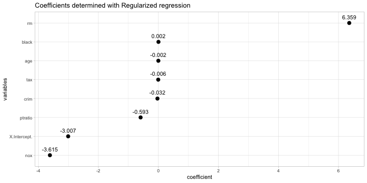

```r
set.seed(1804)
lasso_model <- cv.glmnet(x = data_train_x, y = data_train$medv, nfolds = 5, alpha = 1)
predict_lasso <- predict(lasso_model, s = lasso_model$lambda.1se, data_test_x)
lasso_mse <- round(lasso_model$cvm[lasso_model$lambda == lasso_model$lambda.1se], 3)
lasso_mspe <- round(mean((predict_lasso - data_test$medv)^2), 3)

lasso_params <- data.frame(mspe = lasso_mspe, mse = lasso_mse)

coef(lasso_model, s = "lambda.1se") %>% as.array() %>% as.data.frame() %>%
  rownames_to_column("variable") %>%
  rename("coefficient" = "1") %>% filter(coefficient != 0) %>%
  ggplot(aes(coefficient, reorder(variable, coefficient))) +
  geom_point(show.legend = FALSE, size = 3) +
  geom_text(aes(label = round(coefficient,3)), hjust = 0.5, vjust = -1) +
  theme(text = element_text(size = 7)) + ylab("variables") + theme_light() +
  ggtitle("Coefficients determined with Regularized regression")
```

# Regression Trees

Any dataset can be broken into smaller subgroups hierarchially like a tree, over and over until each observation is by itself a leaf of a tree, giving a perfectly fitted model. Decision tree algorithm works on the same idea, building a large tree and then pruning from the bottom until an acceptable MSE is reached. Something to note is the fact that tree based model perform well on unprocessed data that has not been standardized.

The pruning works a little similar to regularized regression, incorporating a cost-complexity parameter. Cross-validation is performed to get the optimal amount of branches. To understand the idea, here is a model with 10-fold cross validation (`default xval = 10`) and no pruning (`cp = 0`).

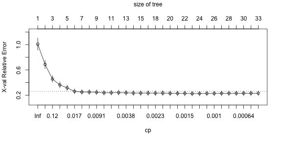

```r
dec_tree_model <- rpart(medv ~ ., data_train, method = "anova",
                        control = list(cp = 0))
plotcp(dec_tree_model)
```

As it can be see, acceptable cv errors are reached as early as 8 branches. Thus, `rpart` will automatically choose that as the default number of branches. The pruned rpart tree is visualized.

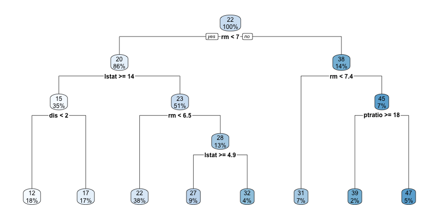

```r
dec_tree_model <- rpart(medv ~ ., data_train, method = "anova")
rpart.plot(dec_tree_model)
```

Interpreting the model, the first split occurs based on `rm` values, and successively at `lstat` and `dis` to get `medv = 12` on the first terminal node. This means that any observation with rm < 7, lstat >= 14 and dis <2 is assigned a median price of 12. Decision tree models will be validated against the test data to calculate MSPE, and the cross-validation error of the model. The function below evaluates both values.

```r
dec_tree_predict <- function(tree_model) {

  least_error <- tree_model$cptable %>% as.data.frame() %>%
    arrange(xerror) %>% head(1)

  tree_predict <- predict(tree_model, data_test)
  tree_mspe <- round(mean((tree_predict - data_test$medv)^2), 3)

  export_params <- list(mspe = tree_mspe,
                        cv_error = round(least_error$xerror, 3),
                        cp = least_error$CP)
  return(export_params)
}
```

The basic model above has an MSPE of 31.463 and a cross-validation error of 0.255.  
On top of pruning and cross-validation, decision trees can be further tuned by adjusting the `minsplit` and `maxdepth` parameters.

- Minsplit refers to the minimum number of observations that must exist in a node before a split is attempted. The smaller the number, higher are the chances of overfitting.
- Maxdepth corresponds to the total number of nodes between each terminal node and root node. Higher the number, larger the tree, meaning it could lead to overfitting.

With this knowledge, we build a grid of models for differente values of minsplit and maxdepth.

```r
dec_tree_tuning <- expand.grid(minsplit = seq(10, 50, by = 2),
                               maxdepth = seq(5, 10),
                               cp = 0,
                               cv_error = 0,
                               mspe = 0)

for (i in 1:nrow(dec_tree_tuning)) {
  set.seed(1804)
  model <- rpart(medv ~ ., data_train, method = "anova",
                 control = list(minsplit = dec_tree_tuning$minsplit[i],
                                maxdepth = dec_tree_tuning$maxdepth[i]))

  model_params <- dec_tree_predict(model)

  dec_tree_tuning$cp[i] <- model_params$cp
  dec_tree_tuning$cv_error[i] <- model_params$cv_error
  dec_tree_tuning$mspe[i] <- model_params$mspe
}
```

The top 5 results, sorted by cross-validation error are printed below. We see tiny improvement of MSPE over the original model.

```r
dec_tree_tuning %>% arrange(cv_error) %>% head(5) %>%
  kable(caption = "Top 5 results of Decision Tree Tuning")
```

Top 5 results of Decision Tree Tuning

| minsplit | maxdepth | cp | cv_error | mspe |
| --- | --- | --- | --- | --- |
| 36 | 5 | 0.01 | 0.261 | 31.409 |
| 38 | 5 | 0.01 | 0.261 | 31.409 |
| 36 | 6 | 0.01 | 0.261 | 31.409 |
| 38 | 6 | 0.01 | 0.261 | 31.409 |
| 36 | 7 | 0.01 | 0.261 | 31.409 |

## Bagging

What if the data is split into multiple chunks and trees are grown over each chunk and then averaged? That’s the idea behind **b**ootstrap **agg**regat**ing**.

The data passed to the function is first split into `train` and `test` data. The `train` data is then bootstrap sampled(random, with replacement) into a number of chunks and unpruned trees are grown over each sample. Predictions are averaged to get the overall value. The `test` data, also called Out Of Bag data is now predicted and the MSE of this test data is used to evaluate model performance.

```r
tree_bag <- bagging(medv ~ ., data_train, coob = TRUE)
tree_bag_oob <- round((tree_bag$err)^2, 3)

tree_bag_predict <- predict(tree_bag, data_test)
tree_bag_mspe <- round(mean((tree_bag_predict - data_test$medv)^2), 3)
```

The out of bag error for this basic model is 15.964 and MSPE on the original test data is 25.463. This is significantly lower than any of the errors so far in all the models.

Bagging creates 25 samples by default. Increasing the number of trees increases the prediction accuracy. In terms of bias-variance trade-off, deeper trees reduce the bias while larger number of trees reduce the variance. Below, we visualize the errors with changing sample count between 10 to 100.

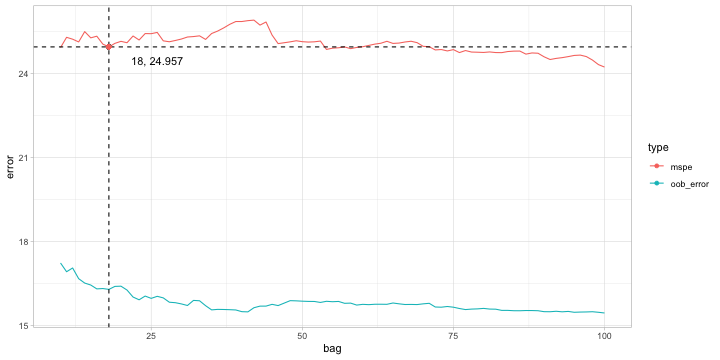

```r
bag_tuning <- expand.grid(bag = seq(10, 100),
                          oob_error = 0,
                          mspe = 0)

for (i in 1:nrow(bag_tuning)) {
  set.seed(1804)
  model <- bagging(medv ~ ., data_train, coob = TRUE, nbagg = bag_tuning$bag[i])
  bag_tuning$oob_error[i] <- round((model$err)^2, 3)

  predict <- predict(model, data_test)
  bag_tuning$mspe[i] <- round(mean((predict - data_test$medv)^2), 3)
}

low_bag_model <- bag_tuning %>% arrange(mspe) %>% filter(bag < 50, bag > 10) %>% head(1)

bag_tuning %>% gather("type", "error", -bag) %>%
  ggplot(aes(bag, error, col = type)) +  geom_line() +
  geom_vline(xintercept = low_bag_model$bag, linetype = "dashed") +
  geom_hline(yintercept = low_bag_model$mspe, linetype = "dashed") +
  geom_point(aes(low_bag_model$bag, low_bag_model$mspe)) + theme_light() +
  annotate("text", x = low_bag_model$bag + 8, y = low_bag_model$mspe - 0.5,
           label = paste0(low_bag_model$bag, ", ", low_bag_model$mspe))
```

The lowest MSPE is achieved with 100 bags with a value of 24.236. But the difference isn’t large enough than, for example, 18-bag model with an mspe of 24.957.

# Random Forests

The idea works very similar to bagging, modelling on bootstrapped data to create multiple trees. However, an additional parameter `mtry` is passed to the function that restricts the number of randomly chosen variables that can be used to build each tree. It essentially forces each tree to be different from one another, coercing all variables to be used in building the model. Setting `mtry` equal to the number of variables is the same as bagging. The rule of thumb, however, is to set mtry at one third of the number of variables. A simple model is built below. `num.trees` here refers to the number of bootstrap sampled trees to be built, same as `n_bagg`.

```r
ranger_model <- ranger(medv ~ ., data_train, num.trees  = 25, seed = 1804,
                       mtry = floor((ncol(data) - 1) / 3))
ranger_oob <- round(ranger_model$prediction.error, 3)

ranger_predict <- predict(ranger_model, data_test)
ranger_predict_mspe <- round(mean((ranger_predict$predictions - data_test$medv)^2), 3)
```

Both the out of bag MSE and the validation test errors drop significantly to 13.338 and 18.129 respectively. We have come a long way from the mid-30’s MSPE of OLS regressions! That doesn’t mean this report is coming to an end. Decision trees can be tuned by running it through a grid of `num.trees`, `mtry`, `min.node.size` and `sample.fraction`.

```r
ranger_tuning <- expand.grid(num_trees = seq(50, 500, by = 10),
                             mtry = seq(2, 7),
                             min_nodes = seq(3, 10),
                             sample_fraction = seq(0.6, 0.8, by = 0.05),
                             oob_error = 0,
                             mspe = 0)

for (i in 1:nrow(ranger_tuning)) {
  model <- ranger(medv ~ ., data_train, seed = 1804, mtry = ranger_tuning$mtry[i],
                  num.trees  = ranger_tuning$num_trees[i],
                  sample.fraction = ranger_tuning$sample_fraction[i],
                  min.node.size = ranger_tuning$min_nodes[i])
  predict <- predict(model, data_test)

  ranger_tuning$oob_error[i] <- round(model$prediction.error, 3)
  ranger_tuning$mspe[i] <- round(mean((predict$predictions - data_test$medv)^2), 3)
}

ranger_tuning %>% arrange(mspe) %>% head(5) %>% kable(caption = "Top 5 models by mspe")
```

Top 5 models by mspe

| num_trees | mtry | min_nodes | sample_fraction | oob_error | mspe |
| --- | --- | --- | --- | --- | --- |
| 60 | 7 | 4 | 0.80 | 12.547 | 13.690 |
| 60 | 7 | 3 | 0.80 | 12.634 | 14.006 |
| 60 | 7 | 5 | 0.80 | 12.616 | 14.111 |
| 50 | 7 | 4 | 0.80 | 12.438 | 14.148 |
| 60 | 6 | 7 | 0.75 | 12.222 | 14.151 |

Unlike regression techniques, random forests suffer from the lack of interpretability. The best it can do is tell us the ‘importance’ of each variable. There are a couple of methods of measuring this importance.

- Impurity - Calculates the improvement in MSE for each variable across all nodes and trees and averaged. Higher the average, higher is the importance.
- Permutation - Calculates the drop in MSE if the actual values passed to the trees during training are altered randomly. Higher the drop, higher the importance.

The importance of different variables, based on impurity and permutation are both visualized for the best model that was evaluated earlier.

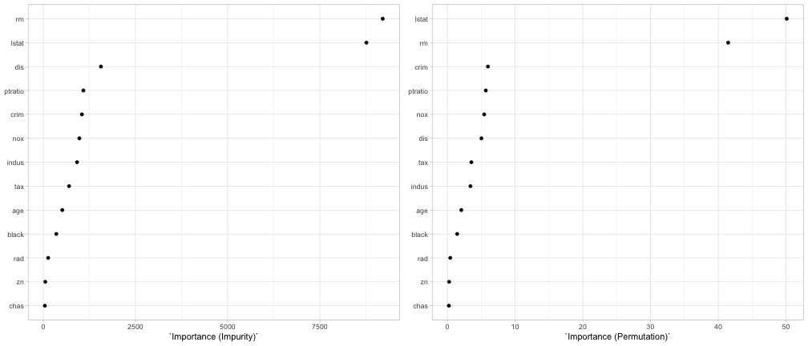

```r
ranger_best_params <- ranger_tuning %>% arrange(mspe) %>% head(1)

ranger_model_imp <- ranger(medv ~ ., data_train, seed = 1804, mtry = ranger_best_params$mtry,
                           num.trees  = ranger_best_params$num_trees,
                           sample.fraction = ranger_best_params$sample_fraction,
                           min.node.size = ranger_best_params$min_nodes,
                           importance = "impurity")

ranger_model_per <- ranger(medv ~ ., data_train, seed = 1804, mtry = ranger_best_params$mtry,
                           num.trees  = ranger_best_params$num_trees,
                           sample.fraction = ranger_best_params$sample_fraction,
                           min.node.size = ranger_best_params$min_nodes,
                           importance = "permutation")

grid.arrange(ranger_model_imp$variable.importance %>% as.data.frame() %>%
               rename("Importance (Impurity)" = ".") %>%
               rownames_to_column("Variable") %>% arrange(Variable) %>%
               ggplot(aes(`Importance (Impurity)`, reorder(Variable, `Importance (Impurity)`))) +
               geom_point() + theme_light() + theme(axis.title.y = element_blank()),

             ranger_model_per$variable.importance %>% as.data.frame() %>%
               rename("Importance (Permutation)" = ".") %>%
               rownames_to_column("Variable") %>% arrange(Variable) %>%
               ggplot(aes(`Importance (Permutation)`, reorder(Variable, `Importance (Permutation)`))) +
               geom_point() + theme_light() + theme(axis.title.y = element_blank()),
             ncol = 2, nrow = 1)
```

# Gradient Boosting

Gradient Boosting Machines are considered the latest and greatest in the world of machine learning. All the tree-based techniques so far have randomly modelled trees and averaged to reach the optimum. GBM’s however, model trees sequentially, learning from the errors of weaker trees. The term `Boosting` here refers to iteratively improving the sequence of decision trees. `Gradient` refers to the negative slope of drop in errors. Tree models are grown sequentially, improving as the error decreases at each step, continuing until the slope flattens out or starts going up. Model is cross-validated at each step to measure the error. The iterative direction of the model growth is based on maximum reduction in error.

We are coming across two new parameters in the `gbm` function

- `shrinkage` is the learning rate that indicates how fast the model is learning. Lower the number, slower, but without the risk of missing an optimum point.
- `bag.fraction` is fraction of training data selected to propose the next tree in the expansion.

A basic implementation is shown below. Since the model did not show any significant performance improvement with large number of trees, we limit the max tree count to `500`.

```r
set.seed(1804)
gbm_model <- gbm(medv ~ . , data_train, distribution = "gaussian", n.trees = 500,
                 train.fraction = 0.75, interaction.depth = 5, verbose = FALSE,
                 shrinkage = 0.3, n.minobsinnode = 12, bag.fraction = 0.75)

gbm_predict <- predict(gbm_model, data_test, gbm_model$n.trees)

gbm_mse <- min(gbm_model$valid.error)
gbm_mspe <- mean((gbm_predict - data_test$medv)^2)
gbm_num_trees <- which.min(gbm_model$valid.error)
```

The model MSE and MSPE of the model are respectively 26.551 and 17.472. It took the model only 11 to reach this error.  
Building a grid, the max number of trees is further brought down to 100, with shrinkage varying between 0.1 to 0.4. As the `n.trees` decreases, it’s imperative to increase `shrinkage` as there are fewer opportunities for the model to learn.

```r
gbm_tuning <- expand.grid(shrinkage = seq(0.1, 0.4, by = 0.02),
                          interaction_depth = seq(1, 8),
                          node_min_obs = seq(4, 12, by = 2),
                          bag_fraction = seq(0.7, 1, by = 0.1),
                          tree_count = 0,
                          mse = 0,
                          mspe = 0)

for (i in 1:nrow(gbm_tuning)) {

  set.seed(1804)
  model <- gbm(medv ~ ., data_train, distribution = "gaussian", n.trees = 100,
               interaction.depth = gbm_tuning$interaction_depth[i],
               shrinkage = gbm_tuning$shrinkage[i],
               n.minobsinnode = gbm_tuning$node_min_obs[i],
               bag.fraction = gbm_tuning$bag_fraction[i],
               verbose = FALSE, train.fraction = 0.75)

  predict <- predict(model, data_test, model$n.trees)

  gbm_tuning$tree_count[i] <- which.min(model$valid.error)
  gbm_tuning$mse[i] <- round(min(model$valid.error), 3)
  gbm_tuning$mspe[i] <- round(mean((predict - data_test$medv)^2), 3)
}

gbm_tuning %>% arrange(mspe) %>% head(5) %>% kable(caption = "Top 5 models by MSPE")
```

Top 5 models by MSPE

| shrinkage | interaction_depth | node_min_obs | bag_fraction | tree_count | mse | mspe |
| --- | --- | --- | --- | --- | --- | --- |
| 0.30 | 8 | 4 | 0.9 | 25 | 21.715 | 10.964 |
| 0.24 | 5 | 4 | 0.8 | 11 | 27.192 | 11.786 |
| 0.26 | 6 | 4 | 0.8 | 78 | 21.851 | 12.037 |
| 0.28 | 5 | 4 | 0.8 | 97 | 20.731 | 12.060 |
| 0.20 | 6 | 4 | 0.8 | 32 | 31.531 | 12.605 |

```r
gbm_tuning <- expand.grid(shrinkage = seq(0.1, 0.4, by = 0.02),
                          interaction_depth = seq(5, 10),
                          node_min_obs = seq(1, 4, by = 1),
                          bag_fraction = seq(0.8, 0.9, by = 0.05),
                          tree_count = 0,
                          mse = 0,
                          mspe = 0)

for (i in 1:nrow(gbm_tuning)) {

  set.seed(1804)
  model <- gbm(medv ~ ., data_train, distribution = "gaussian", n.trees = 100,
               interaction.depth = gbm_tuning$interaction_depth[i],
               shrinkage = gbm_tuning$shrinkage[i],
               n.minobsinnode = gbm_tuning$node_min_obs[i],
               bag.fraction = gbm_tuning$bag_fraction[i],
               verbose = FALSE, train.fraction = 0.75)

  predict <- predict(model, data_test, model$n.trees)

  gbm_tuning$tree_count[i] <- which.min(model$valid.error)
  gbm_tuning$mse[i] <- round(min(model$valid.error), 3)
  gbm_tuning$mspe[i] <- round(mean((predict - data_test$medv)^2), 3)
}

gbm_tuning %>% arrange(mspe) %>% head(10) %>% kable(caption = "Top 10 models by MSPE")
```

Top 10 models by MSPE

| shrinkage | interaction_depth | node_min_obs | bag_fraction | tree_count | mse | mspe |
| --- | --- | --- | --- | --- | --- | --- |
| 0.26 | 8 | 2 | 0.80 | 79 | 18.485 | 9.085 |
| 0.32 | 5 | 2 | 0.80 | 27 | 19.712 | 10.068 |
| 0.34 | 6 | 2 | 0.80 | 23 | 21.121 | 10.097 |
| 0.20 | 9 | 2 | 0.80 | 45 | 24.789 | 10.125 |
| 0.24 | 8 | 2 | 0.80 | 93 | 25.921 | 10.152 |
| 0.12 | 7 | 2 | 0.85 | 80 | 21.357 | 10.265 |
| 0.24 | 6 | 2 | 0.80 | 91 | 22.718 | 10.312 |
| 0.24 | 10 | 2 | 0.80 | 32 | 20.049 | 10.596 |
| 0.34 | 10 | 2 | 0.80 | 25 | 21.051 | 10.675 |
| 0.22 | 7 | 2 | 0.80 | 52 | 23.063 | 10.680 |

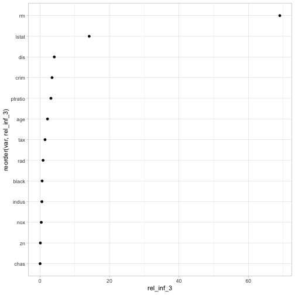

```r
set.seed(1804)
gbm_best_params <- gbm_tuning %>% arrange(mspe) %>% head(1)

gbm_best_params <- data.frame(shrinkage = 0.3,
                          interaction_depth = 10,
                          node_min_obs = 4,
                          bag_fraction = 0.9,
                          tree_count = 0,
                          mse = 0,
                          mspe = 0)

gbm_best_model <- gbm(medv ~ ., data_train, distribution = "gaussian", n.trees = 100,
                      interaction.depth = gbm_best_params$interaction_depth[1],
                      shrinkage = gbm_best_params$shrinkage[1],
                      n.minobsinnode = gbm_best_params$node_min_obs[1],
                      bag.fraction = gbm_best_params$bag_fraction[1],
                      verbose = FALSE, train.fraction = 0.75)

summary(gbm_best_model, cBars = ncol(data),
        method = relative.influence, las = 2, plotit = FALSE) %>%
  mutate(rel_inf_3 = round(rel.inf, 3)) %>%
  ggplot(aes(rel_inf_3, reorder(var, rel_inf_3))) + geom_point() + theme_light()
```

# Summary

Source file associated with this report can be found [here](https://github.com/mr-hn/bostonRegression).  
[LinkedIn](https://linkedin.com/in/harish-morekonda)

Styled with knitrBootstrap